# Your Digest for Monday, Jan 08, 2024 11:59 PM

#2023BSQ-NOV/Q14  
| Type 1 | Type 2 |  
| ---- | ---- |  
| Erythema of previous lesions | Subcutaneous painful nodules + constitutional symptoms |  
| managed with corticosteroid | |  
| Neuritis | |

> [!INFO]  
> ?can occur even before commencement of antibiotic treatment.  
> Can occur within 3 years of the disease. Beyond 3 years, it's unlikely to be a lepra reaction.  
> Leprosy relapses can occur about 5 years after treatment. But these can mimick lepra reactions. The time of onset is what separates the two, clinically.

> Relapses usually occur due to poor compliance or very high bacterial load at outset of treatment.
- May rupture and discharge pus but **they contain only dead bacteria** and neutrophils -> **sterile on culture**.
- Caused by two *clinically indisginguishable* organisms: **M leprae and M. lepromatosis**;

# Dermatologic / cutaneous manifestations of internal malignancy

- **Type 1** - caused by cryoprecipitable **monoclonal immunoglobulins**.
- Cryoglobulinaemia in chronic hepatitis

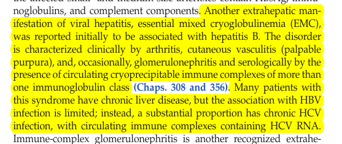

#2023BSQ-NOV/Q12

- 6 bees lick pollen
- "The internal elastic lamina is **a fenestrated sheet that forms the boundary between the intimal and medial layers**, influencing both its mechanical and mass transport properties"
- Neovascularization produces vessels which can rupture into the plaque and cause haemorrhage into it.
- upto 20% can present with **olioarthritis**
- Can be a **manifestation of systemic infection** like infective endocarditis
- *Disseminated gonococcal infection* can present with oligoarthirits
- **Commonest site is the knee**.

***

## Introduction to liver masses

- The liver and lungs are the organs most commonly involved in metastasis.
- Most liver cancers are **metastatic deposits.** (from colon, lung and breast)
- The *vast majority of 'intrinsic' liver cancers* are **hepatocellular carcinomas**.
  - Two other types (hepatoblastoma and angiosarcoma are very very rare)
- The most common **benign** lesions are **cavernous hemangiomas**
  - Soft, <2cm nodules.
  - Can be mistaken for metastatic deposits.
  - But *biopsy can cause catastrophic bleeding*!
- Another benign lesions is **Focal nodular hyperplasia**
  - Seen most often in women of reproductive age.
  - Non neoplastic nodules which form around intrahepatic vascular abnormalities.
  - Poorly capsulated
  - Growth stimulated by oestrogen
- the 3rd benign lesion is **hepatic adenoma**
  - No malignant potential but they **can rupture** causing catastrophic intra-abdominal haemorrhage.
  - Uncapsulated
  - Growth stimulated by oestrogen

### Benign liver lesions

| Cavernous hemangiomas | Focal nodular hyperplasia | Hepatic adenoma |
| --- | --- | --- |
| Commonest |  |  |
| Bleeding if biopsied! |  | Can rupture and bleed |
|  | Pressure symptoms+ | Pressure symptoms+ |
|  | Oestrogen dependent | Oestrogen dependent |
|  | commonest in W of CBA | also in W of CBA |
| *smooth*, well delineated *margins* | *Smooth margins* | *Smooth margins* |
| Peripheral enhancement with centripetal filling | Hyperintense signal | Peripheral enhancement with centripetal filling |
| Fortunately, most liver lesions have a characteristics enhancement pattern on contrast imaging. |  |  |

> "A *hepatocellular carcinoma*, a highly vascular primary lesion, will demonstrate hyperenhancement in the arterial phase and venous or delayed phase washout whilst a hemangioma should match the blood pool in each phase (same as the aorta in arterial etc)." - [Source](https://radiopaedia.org/articles/ct-triple-phase-liver-protocol)

> **70% of hepatic blood flow comes from the portal vein**

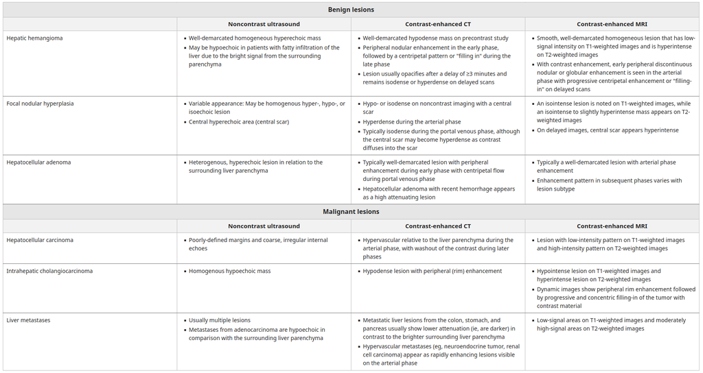

## Hepatocellular carcinomas

> [!TIP] SUMMARY:
> - Occurs in chronic liver disease
> - Aggressive
> - Typically diagnosed late. (Median survival 6-20 months)
> - Difficult to treat -> high rate of recurrence

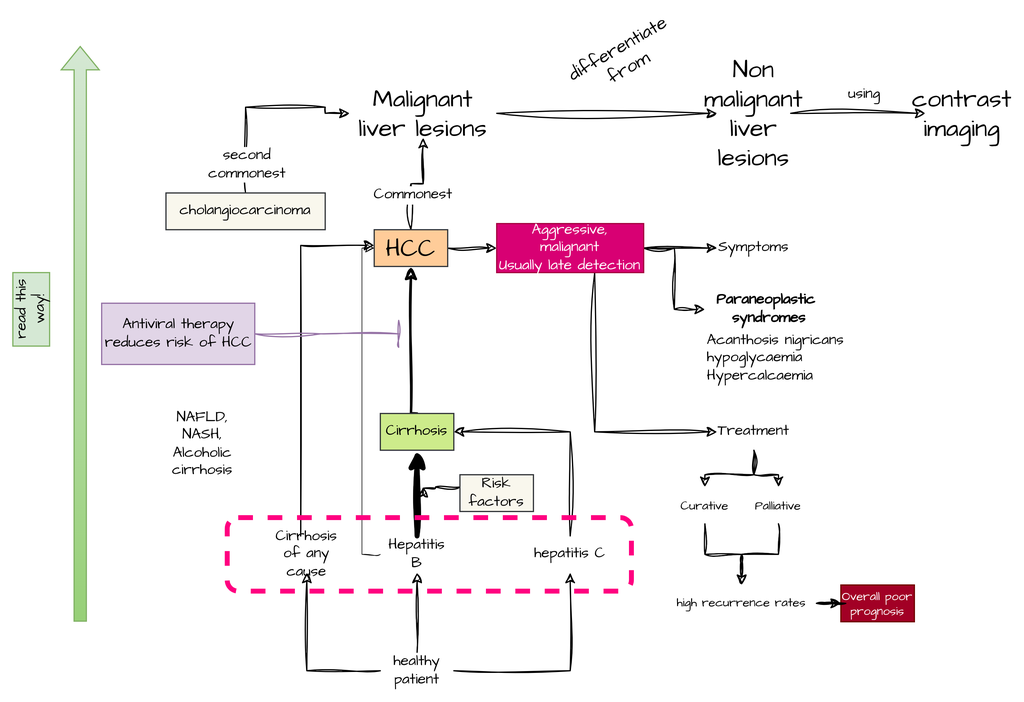

> - **75 percent of primary liver tumors are HCC**
> - **cholangiocarcinoma** ≈ remaining 25%  
>   They are aggressive tumours, usually diagnosed late, with medial survival of 6-20 months.  
>   + Factors increasing risk of HCC in background of chronic **HBV**:  
>   + **High viral load** (high HBV DNA level)  
>   + Similar story for HCV -> In patient with chronic HCV, HCC occurs *almost exclusively in those **who have developed cirrhocis***. (i.e Cirrhosis due to HCV is a significant risk factor)  
>   + **Aflatoxin B1** - mycotoxin present in corn  
>   + *Betel nut chewing*!😱  
>   +

[figure not shown]

>   + **NAFLD** and **NASH** are risk factors
- **Antiviral therapy in chronic HBV or HCV reduces risk of HCC**
  - *Statins, Metformin, Aspirin and other NSAIDS are associated with lower risk of HCC*.
- portal obstruction -> Variceal bleeding / ascites
- **Hypoglycemia** <- metabolic demand of tumour
- **hypercalcaemia**<- secretion of PTH related protein
- **erythrocytosis** <- EPO secretion
- Alpha-Fetoproten level > 20 is a cutoff for further investigation. Sensitivity is only 60%. 😯 <-**can't use it to rule out disease**!
- Specificity - 80%. <- **can use it to rule IN disease**  
  **Diagnosis** can be made with dynamic *contrast-enhanced computed tomography (CT)* or magnetic resonance imaging *(MRI)* tailored for liver lesion evaluation. (Aka **Triple phase CT**)  
  **Imaging diagnosis can obviate need for biopsy**.  
  **Potentially curative**:
- Resection - curative in eligible patients; tumour should not show vascular invasion to be resectable.
- Thermal ablation - similar eligibility criteria to resection, but resection generally preferred.
- Liver transplantation - For patients who are not surgical candidates due to underlying liver disease.  
  **Palliative**:
- Locoregional liver directed therapy - isolated, unresectable HCC who are ineligible for transplantation and who have a limited intrahepatic tumor burden (TARE, TACE, thermal ablation)

> Pirates -> rum -> cirrhosis  
> This glomerulonephritis produces as nephrotic pattern.

[figure not shown]

> | Feature | Hepatitis B | Hepatitis C |  
> | ---- | ---- | ---- |  
> | Epidemiology | est. 220 million carriers | est. 70 million carriers |  
> | Virus type | DNA | SS-RNA |  
> | Transmission | **Vertical**(during birth) is common  
> Hep B in children is a main issue | Vertical transmission is rare |  
> | | Blood + products | **Blood + products**, needle sharing |  
> | Vaccine | Present | Rapid mutations -> No vaccine |  
> | Clinical course | **Acute**: 70% subclinical (anicteric)  
> 30% icteric hepatitis  
> 1% - fulminant hepatitis  
> Overall, in vast majority disease is self limited. | **Acute**: Asymptomatic but 10% will have flu like symp.  
> Overall about 25% will clear the infection spontaneously. |  
> | | **Chronic**: 5% of acute infection becomes chronic | **Chronic**: **90%** of asymptomatic acute infection becomes chronic.  
> 50% of symptomatics become chronic. |  
> | Chronic infection | **4 phases:** | |  
> | | HBeAg+, normal ALT, High DNA  
> HBeAg+, fluctuating ALT, fluctuating DNA  
> HBeAg-, normal ALT, low DNA  
> HBeAg-, fluctuating ALT, fluctuating DNA | |  
> | Outcome of chronic infection | 15% cirrhosis *of which* 20% decompensate and 5% get HCC. | Cirrhosis is slowly progressive  
> 15% get cirrhosis at 20 years *of which* 5% decompensate per year, 1% get HCC per year and 4% die per year. |  
> | HDV relationship | **Coinfection** -> usually self limited; but⬆ risk of acute liver failure (compared to superinfection).  
> No increased risk of chronic infection. | None |  
> | | **Superinfection**: **ALL** develop chronic HBV  
> can present as acute severe hepatitis. | None |  
> | | **Chronic HDV** -> rapid progression to *cirrhosis*. | None |  
> | HCC association | Accounts for **50% of HCC**; mostly after onset of cirrhosis. | accounts for **20% of HCC**; but HCC only occurs after cirrhosis has developed. |  
> | | ⬆viral load increases risk | |  
> | | | Immune complexe mediated extrahepatic phenomena are less common in Hep C than in Hep B, **except for essential mixed cryoglobulinaemia** |  
> | Extrahepatic manifestations | "Serious Pirates Plundered Nine gold diamond chests" | Arthritis, myalgia, Sjogrens, kerato. conj. sicca, Mooren corneal ulcer, porphyria cutanea tarda, lichen planus, asymptomatic mixed cryoglobulinaemia (Type II cgb), *membranoproliferative glomerulonephritis* |  
> | | Initially cryoglobulinaemia was described in hepaitits B | Essential mixed Cryoglobulinaemia is commoner in Hep C:  
> Mnemonic: C-C |  
> | Treatment | | 90% clearance rate with treatment! |

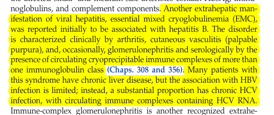